# Lab II: Housing Price Prediction

Zifeng Zhao

week 03 session 02

In this lab, we will build linear regression, GAM and neural networks for predicting resale values of a house.

## 1. Data exploration and visualization

Let’s read in the data from `WestRoxbury.csv` and further conduct some data visualization.

```r
total_data <- read.csv("~/Desktop/ASI/week03session02/WestRoxbury.csv", header=T, stringsAsFactors=T)
str(total_data)
```

```
## 'data.frame':    5801 obs. of  11 variables:
##  $ total_value: num  344 413 330 499 332 ...
##  $ lot_sqft   : int  9965 6590 7500 13773 5000 5142 5000 10000 6835 5093 ...
##  $ yr_built   : int  1880 1945 1890 1957 1910 1950 1954 1950 1958 1900 ...
##  $ gross_area : int  2436 3108 2294 5032 2370 2124 3220 2208 2582 4818 ...
##  $ living_area: int  1352 1976 1371 2608 1438 1060 1916 1200 1092 2992 ...
##  $ floors     : num  2 2 2 1 2 1 2 1 1 2 ...
##  $ rooms      : int  6 10 8 9 7 6 7 6 5 8 ...
##  $ full_bath  : int  1 2 1 1 2 1 1 1 1 2 ...
##  $ half_bath  : int  1 1 1 1 0 0 1 0 0 0 ...
##  $ fireplace  : int  0 0 0 1 0 1 0 0 1 0 ...
##  $ remodel    : Factor w/ 3 levels "None","Old","Recent": 1 3 1 1 1 2 1 1 3 1 ...
```

**Exercise 1** Create a scatter plot between `total_value` and `rooms`. Note that `rooms` is a numerical predictor but only takes a finite number of values. Thus, let’s further make a boxplot between `total_value` and `rooms`, which is more informative.

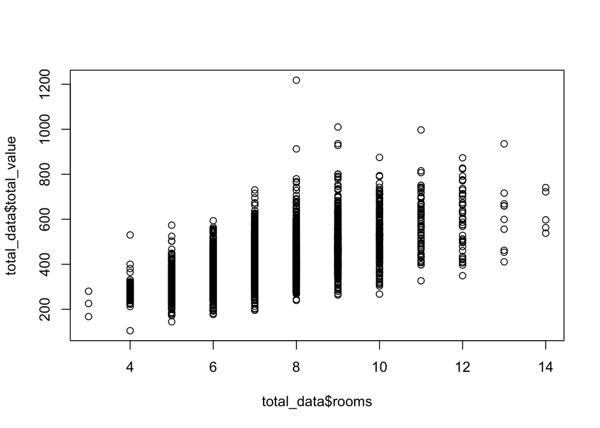

```r
plot(total_data$rooms, total_data$total_value)
```

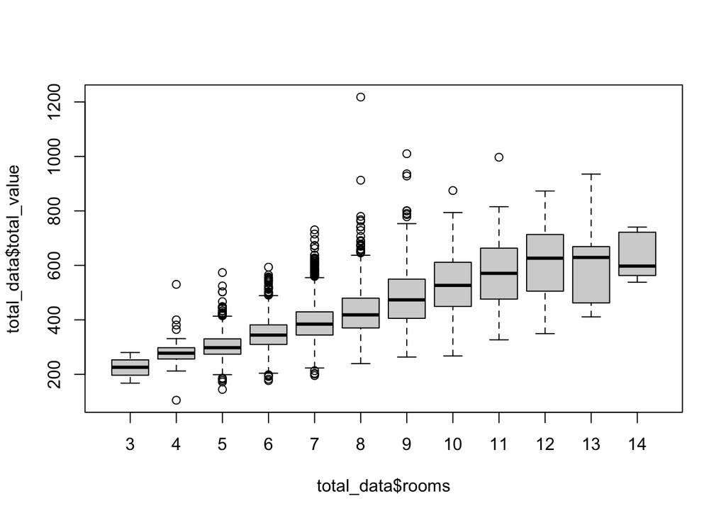

```r
boxplot(total_data$total_value ~ total_data$rooms)
```

**Exercise 2** Create a boxplot between `total_value` and `remodel`. Does remodeling help increase house value?

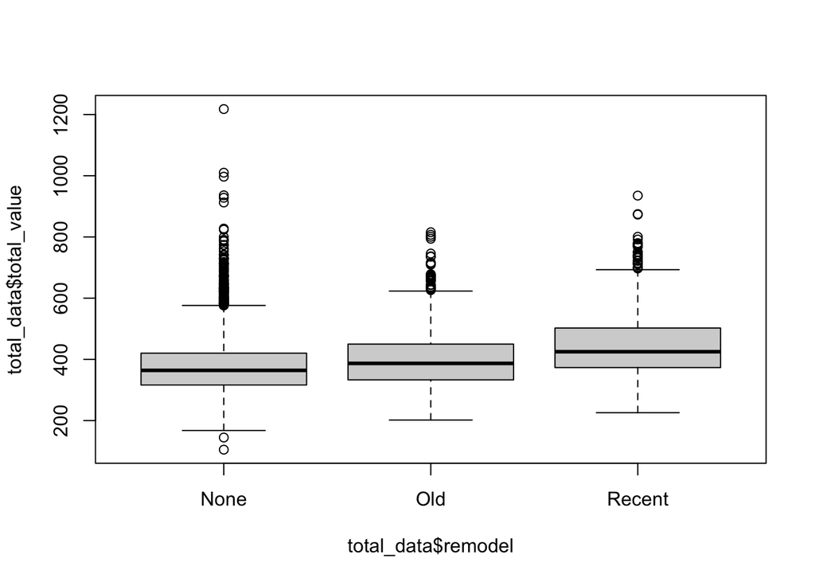

```r
boxplot(total_data$total_value ~ total_data$remodel)
```

Answer: Remodeling does help increase house values because the boxplot shows that houses with recent remodeling have higher average values.

**Exercise 3** Create a scatter plot between `total_value` and `yr_built`. Is there any non-linear effect? Similarly, create a scatter plot between `total_value` and `living_area` and investigate the relationship.

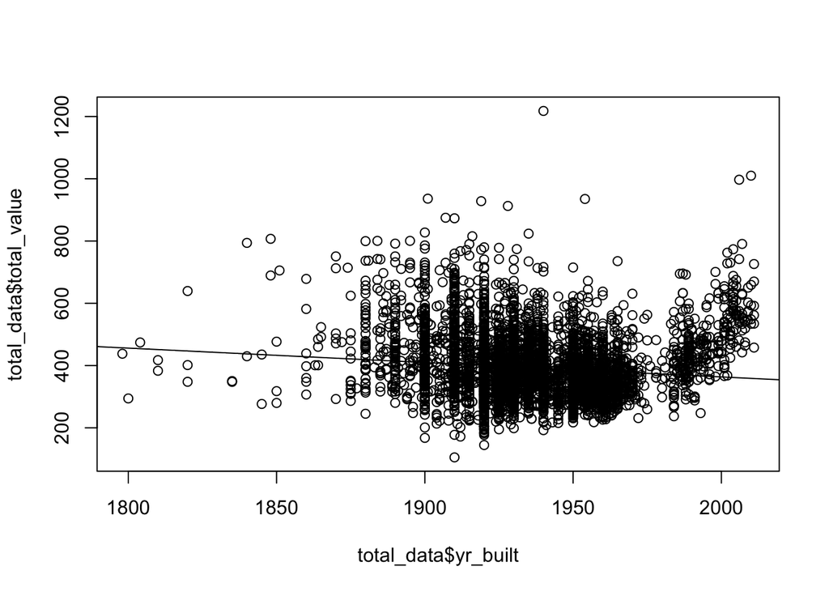

```r
plot(total_data$total_value ~ total_data$yr_built)
abline(lm(total_value ~ yr_built, data = total_data))
```

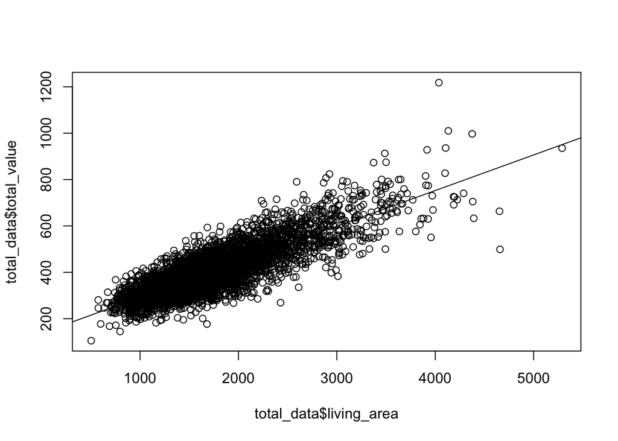

```r
plot(total_data$total_value ~ total_data$living_area)
abline(lm(total_value ~ living_area, data = total_data))
```

Answer: The scatter plot shows that there is a small negative relationship between to `total_value` and `yr_built`, but it does not look like `yr_built` is a good predictor. On the other hand, there is a clear positive relationship between `total_value` and `living_area`.

**Exercise 4** Plot the histogram of `total_value`. Do we need a log transformation? If so, further create a `log_total_value` variable in the `R` object `total_data` using the formula $\widetilde{Y}=\log(Y+1).$

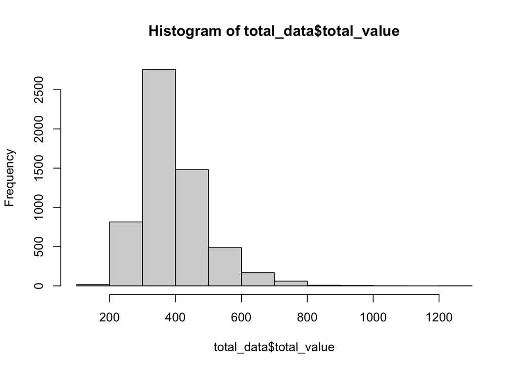

```r
hist(total_data$total_value)
```

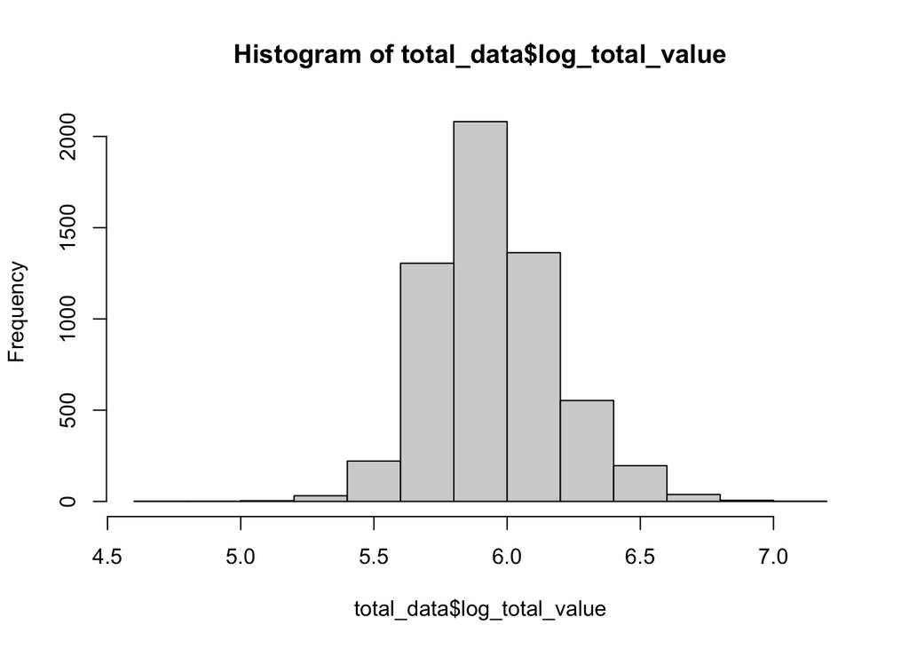

```r
# Because the data is showing there are some skewness because of some extreme outliers, we need to do a log transformation to make it a normal distribution.

total_data$log_total_value <- log(total_data$total_value + 1)

hist(total_data$log_total_value)
```

## 2. Linear regression, GAM and NN

### 2.1 Data partition

**Exercise 5** In total, we have 5801 observations, which is a decent sample size. Thus, let’s partition the data in `total_data` into training **(70%)** and test data **(30%)** and store them as `R` objects `train_data` and `test_data` respectively. Use random seed **`set.seed(7)`**!

```r
set.seed(7)
total_obs <- dim(total_data)[1]
train_data_indices <- sample(1:total_obs, 0.7 * total_obs)
train_data <- total_data[train_data_indices,]
test_data <- total_data[-train_data_indices,]
```

### 2.2 Linear regression

**Exercise 6** Estimate a linear regression model with all **10** predictors `lot_sqft+yr_built+gross_area+living_area+floors+rooms+full_bath+half_bath+fireplace+remodel` and name it `lm1`. Note the dependent variable should be `log_total_value`.

```r
lm1 <- lm(log_total_value ~ lot_sqft + yr_built + gross_area +
          living_area +  floors + rooms + full_bath + half_bath +
          fireplace + remodel, data = train_data)

summary(lm1)
```

```
##
## Call:
## lm(formula = log_total_value ~ lot_sqft + yr_built + gross_area +
##     living_area + floors + rooms + full_bath + half_bath + fireplace +
##     remodel, data = train_data)
##
## Residuals:
##      Min       1Q   Median       3Q      Max
## -0.74755 -0.06403  0.00655  0.07040  0.38045
##
## Coefficients:
##                Estimate Std. Error t value Pr(>|t|)
## (Intercept)   4.239e+00  1.549e-01  27.361  < 2e-16 ***
## lot_sqft      2.033e-05  7.369e-07  27.583  < 2e-16 ***
## yr_built      4.259e-04  7.819e-05   5.447 5.42e-08 ***
## gross_area    8.192e-05  4.896e-06  16.731  < 2e-16 ***
## living_area   8.160e-05  9.038e-06   9.029  < 2e-16 ***
## floors        1.264e-01  4.979e-03  25.394  < 2e-16 ***
## rooms         6.650e-03  1.771e-03   3.754 0.000176 ***
## full_bath     3.575e-02  4.118e-03   8.681  < 2e-16 ***
## half_bath     5.241e-02  3.760e-03  13.939  < 2e-16 ***
## fireplace     4.284e-02  3.162e-03  13.550  < 2e-16 ***
## remodelOld    1.646e-02  5.825e-03   2.825 0.004747 **
## remodelRecent 6.587e-02  4.988e-03  13.206  < 2e-16 ***
## ---
## Signif. codes:  0 '***' 0.001 '**' 0.01 '*' 0.05 '.' 0.1 ' ' 1
##
## Residual standard error: 0.1073 on 4048 degrees of freedom
## Multiple R-squared:  0.787,  Adjusted R-squared:  0.7864
## F-statistic:  1360 on 11 and 4048 DF,  p-value: < 2.2e-16
```

### 2.3 Generalized additive model

**Exercise 7** Estimate a generalized additive model with all **10** predictors `s(lot_sqft,df=4)+s(yr_built,df=4)+s(gross_area,df=4)+s(living_area,df=4)+floors+rooms+full_bath+half_bath+fireplace+remodel` and name it `gam1`. Note that for numerical predictors `lot_sqft`, `yr_built`, `gross_area` and `living_area`, we specify them as splines with degree-of-freedom=4.

```r
library(gam)
gam1 <- gam(log_total_value ~ s(lot_sqft,df=4) + s(yr_built,df=4) +
              s(gross_area,df=4) + s(living_area,df=4) + floors +
              rooms + full_bath + half_bath + fireplace + remodel, data = total_data)
```

**Exercise 8** Plot the estimated coefficient functions for `gam1` using the function `plot()`. Does GAM capture the non-linear effect of numerical predictors `lot_sqft`, `yr_built`, `gross_area` and `living_area`?

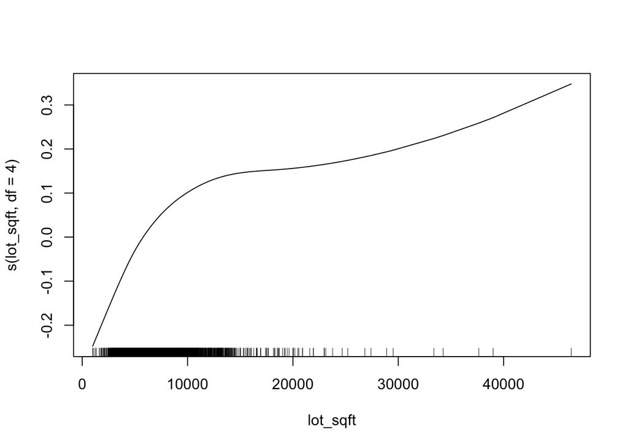

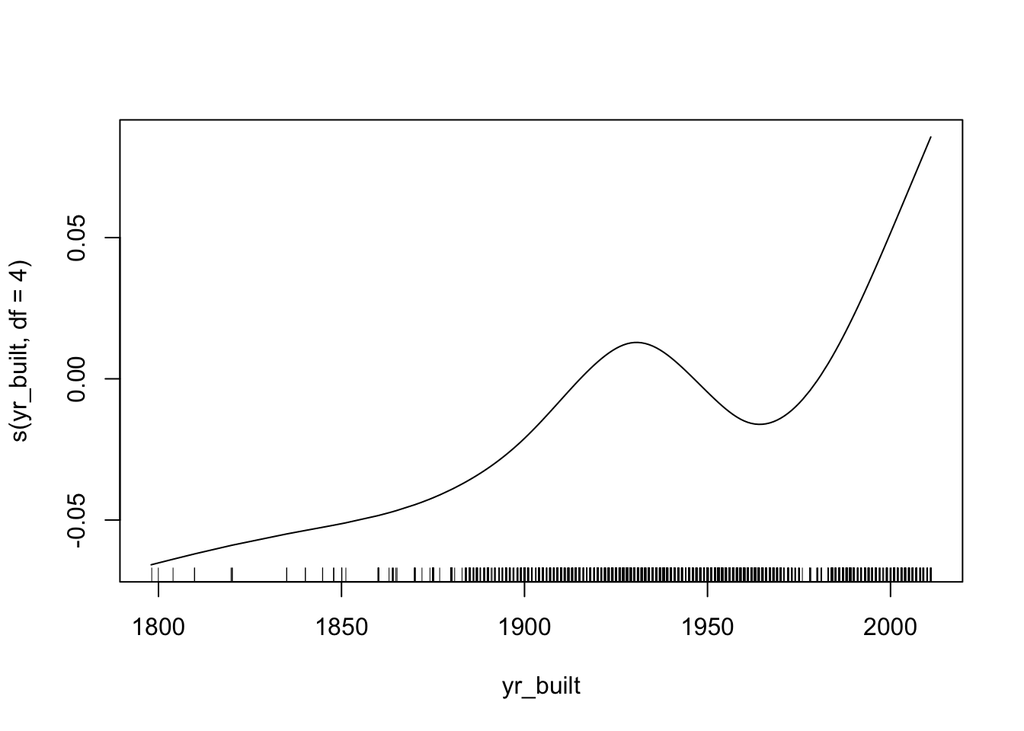

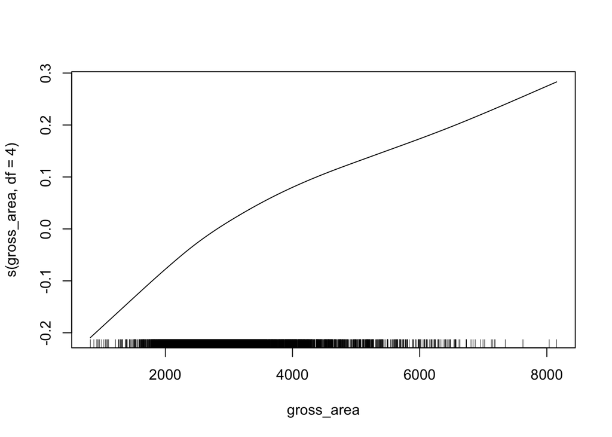

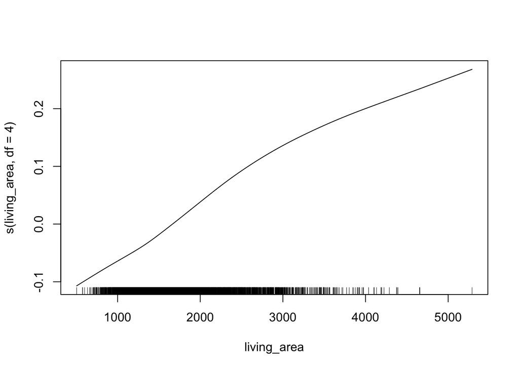

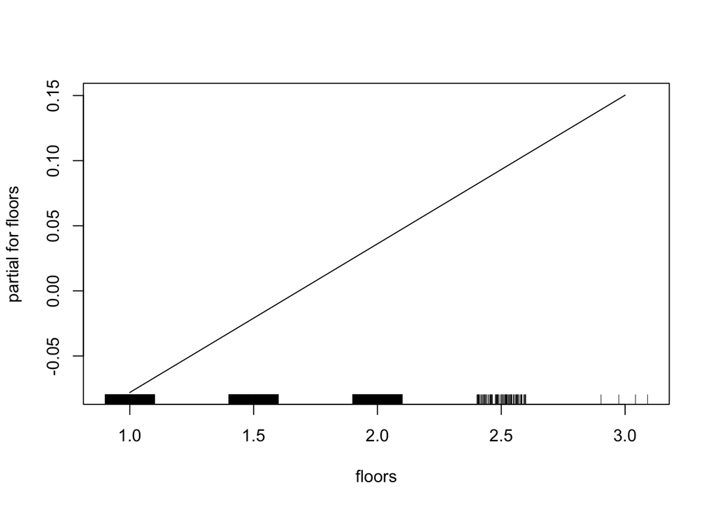

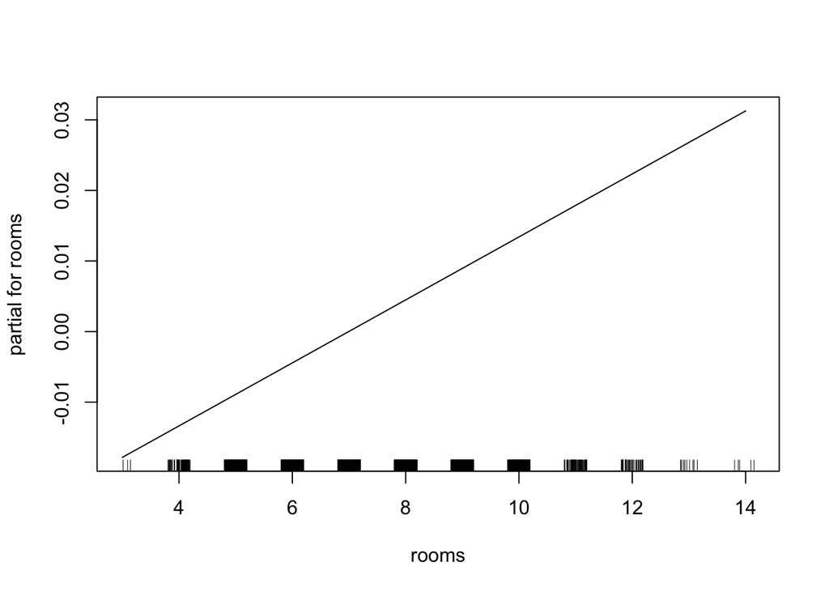

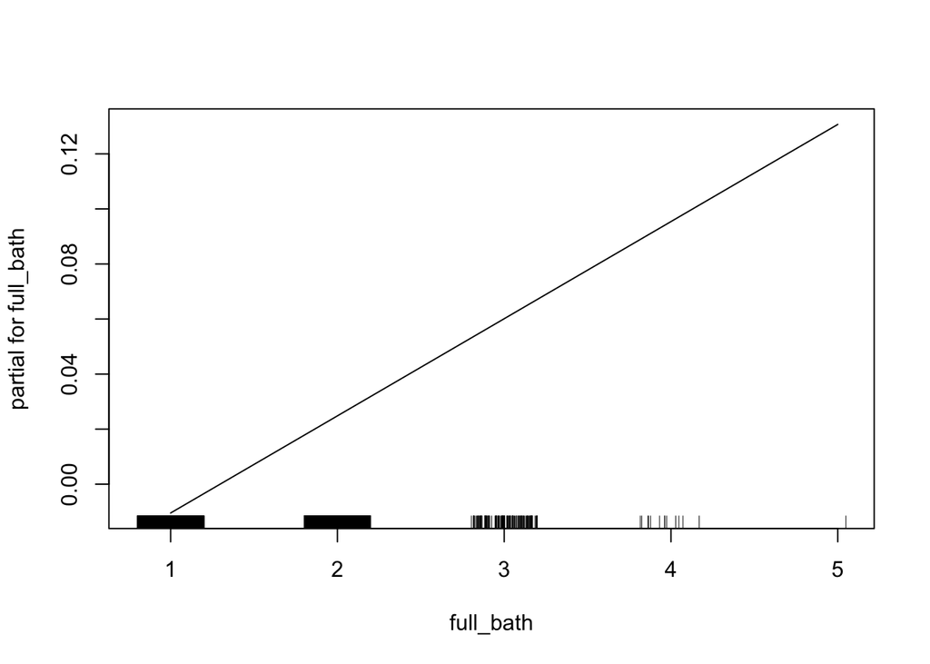

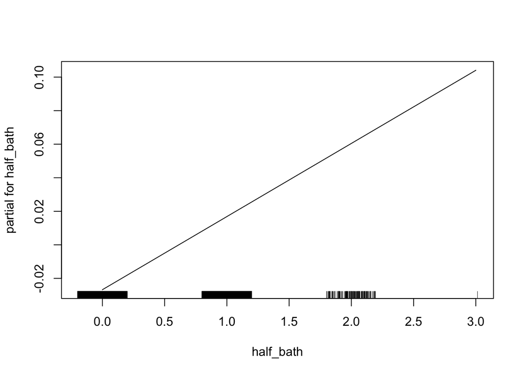

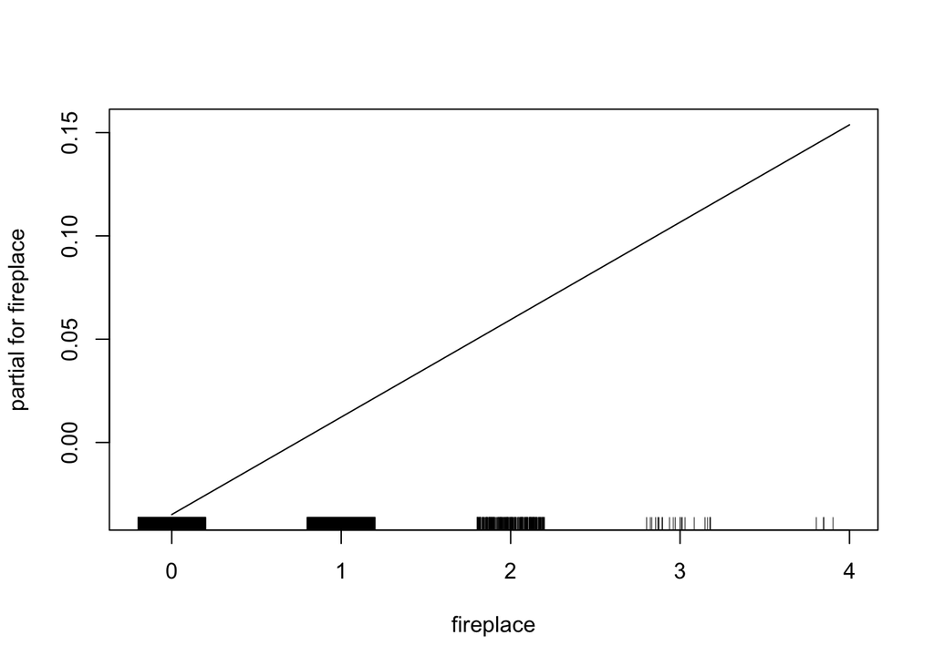

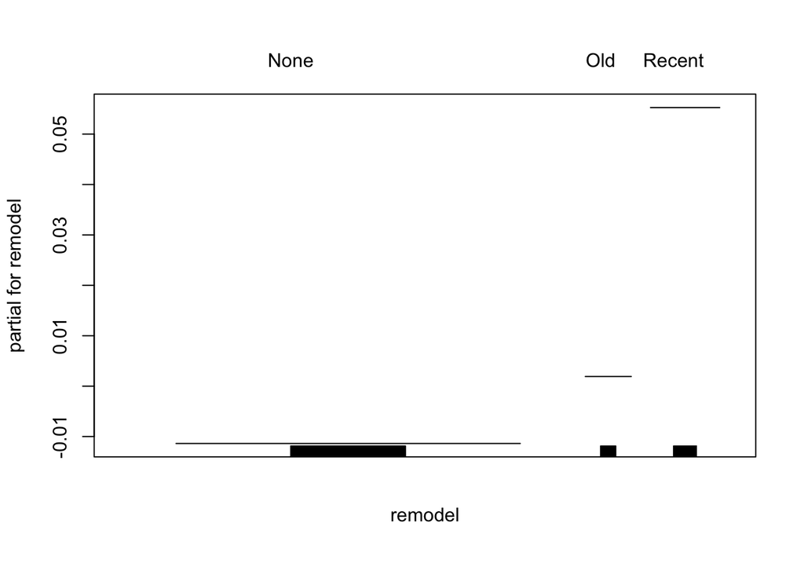

```r
plot(gam1)
```

Answer: GAM does capture the non-linear effect of numerical predictors `lot_sqft`, `yr_built`, `gross_area` and `living_area`.

### 2.4 Neural networks

Estimate an NN with all **10** predictors, name it `nn1`. For the architecture of NN, let’s use two hidden layers with 4 hidden units in the first layer and 4 hidden units in the second layer.

**Exercise 9** Let’s first generate the **training dataset** that are needed for the estimation of NN using the function `model.matrix()` and store it in `x_train_nn`. In addition, use the `scale()` function to standardize the predictors by centering with mean and scaling with sd. In addition, combine the `log_total_value` with the standardized predictors stored in `x_train_nn`. Make sure to rename the column name of `x_train_nn` correctly for `log_total_value`!

```r
x_train_nn <- model.matrix(~ lot_sqft + yr_built + gross_area +
          living_area +  floors + rooms + full_bath + half_bath +
          fireplace + remodel, data = train_data)[, -1]

x_mean <- apply(x_train_nn, 2, mean)

x_sd <- apply(x_train_nn, 2, sd)

x_train_nn <- scale(x_train_nn, center = x_mean, scale = x_sd)

x_train_nn <- cbind.data.frame(train_data$log_total_value, x_train_nn)

colnames(x_train_nn)[1] <- 'log_total_value'
```

**Exercise 10** Let’s further generate the **test dataset** that are needed for the out-of-sample prediction evaluation of NN using the function `model.matrix()` and store it in `x_test_nn`. Use the `scale()` function to standardize the predictors by centering with mean and scaling with sd as in Exercise 9.

```r
x_test_nn <- model.matrix(~ lot_sqft + yr_built + gross_area +
          living_area +  floors + rooms + full_bath + half_bath +
          fireplace + remodel, data = test_data)[, -1]

x_test_nn <- scale(x_test_nn, center = x_mean, scale = x_sd)
```

**Exercise 11** Let’s fit an NN that has two hidden layers with 4 hidden units in the first layer and 4 hidden units in the second layer. Make sure to use random seed **`set.seed(7)`**!

```r
set.seed(7)
library(neuralnet)

nn1 <- neuralnet(log_total_value~., data = x_train_nn, hidden = c(4,4))

plot(nn1)
```

[output not shown]

### 2.5 Model evaluation (out-of-sample)

Let’s now evaluate the prediction performance of the three statistical models `lm1`, `gam1` and `nn1` on the test data. First, let’s generate the prediction by each model and store them in `lm1_pred`, `gam1_pred` and `nn1_pred` respectively. Make sure to transform the prediction back to the **original** scale. We then use the `accuracy()` function from the `forecast` package to obtain the error metrics.

```r
library(forecast)
lm1_pred <- exp(predict(lm1, newdata = test_data)) - 1
gam1_pred <- exp(predict(gam1, newdata = test_data)) - 1
nn1_pred <- exp(predict(nn1, newdata = x_test_nn)[,1]) - 1

accuracy(lm1_pred, test_data$total_value)
```

```
##                 ME    RMSE      MAE        MPE     MAPE
## Test set 0.4164638 50.9286 34.50307 -0.9913653 8.699305
```

```r
accuracy(gam1_pred, test_data$total_value)
```

```
##                ME     RMSE      MAE        MPE     MAPE
## Test set 1.432899 42.18246 30.90475 -0.7490357 7.876437
```

```r
accuracy(nn1_pred, test_data$total_value)
```

```
##                 ME     RMSE      MAE        MPE     MAPE
## Test set 0.8572353 43.56849 31.41609 -0.8631197 7.922241
```

**Exercise 12** Which model should we choose and why?

### 3. Statistical analysis on the original-scale `total_value`

**Exercise 13** Let’s estimate linear regression and GAM as before but with the **original scale** `total_value` and name them `lm2` and `gam2` respectively.

```r
# lm2 and gam2
lm2 <- lm(total_value ~ lot_sqft + yr_built + gross_area +
            living_area + floors + rooms + full_bath + half_bath +
            fireplace + remodel, data = train_data)
summary(lm2)
```

```
##
## Call:
## lm(formula = total_value ~ lot_sqft + yr_built + gross_area +
##     living_area + floors + rooms + full_bath + half_bath + fireplace +
##     remodel, data = train_data)
##
## Residuals:
##      Min       1Q   Median       3Q      Max
## -220.566  -25.955   -0.291   25.842  207.959
##
## Coefficients:
##                 Estimate Std. Error t value Pr(>|t|)
## (Intercept)   -2.396e+02  6.055e+01  -3.956 7.74e-05 ***
## lot_sqft       8.666e-03  2.880e-04  30.093  < 2e-16 ***
## yr_built       1.390e-01  3.056e-02   4.549 5.54e-06 ***
## gross_area     3.565e-02  1.914e-03  18.630  < 2e-16 ***
## living_area    4.347e-02  3.532e-03  12.307  < 2e-16 ***
## floors         4.306e+01  1.946e+00  22.129  < 2e-16 ***
## rooms          1.063e+00  6.921e-01   1.535    0.125
## full_bath      1.843e+01  1.609e+00  11.451  < 2e-16 ***
## half_bath      1.932e+01  1.469e+00  13.149  < 2e-16 ***
## fireplace      1.704e+01  1.236e+00  13.794  < 2e-16 ***
## remodelOld     5.864e+00  2.276e+00   2.576    0.010 *
## remodelRecent  2.430e+01  1.949e+00  12.467  < 2e-16 ***
## ---
## Signif. codes:  0 '***' 0.001 '**' 0.01 '*' 0.05 '.' 0.1 ' ' 1
##
## Residual standard error: 41.93 on 4048 degrees of freedom
## Multiple R-squared:  0.8145, Adjusted R-squared:  0.814
## F-statistic:  1616 on 11 and 4048 DF,  p-value: < 2.2e-16
```

```r
gam2 <- gam(total_value~s(lot_sqft,df=4) + s(yr_built,df=4) +
               s(gross_area,df=4) + s(living_area,df=4) + floors +
               rooms + full_bath + half_bath + fireplace +
              remodel, data = train_data)
```

**Exercise 14** Let’s estimate NN as before but with the **original scale** `total_value` and name them `nn2`. Note that for the original scale `total_value`, we indeed need to further standardize the dependent variable `total_value` by dividing its maximum value.

```r
# generate training dataset for NN and standardize the predictors
x_train_nn <- model.matrix( ~ lot_sqft + yr_built + gross_area +
                             living_area + floors + rooms +
                             full_bath + half_bath + fireplace +
                              remodel, data = train_data)[,-1]

# standardize the dependent variable total_value for numerical stability
x_mean <- apply(x_train_nn, 2, mean)
x_sd <- apply(x_train_nn, 2, sd)

x_train_nn <- scale(x_train_nn, center=x_mean, scale=x_sd)

# standardize the dependent variable total_value for numerical stability
y_max <- max(train_data$total_value)

x_train_nn <- cbind.data.frame(train_data$total_value/y_max, x_train_nn)
colnames(x_train_nn)[1] <- 'st_total_value'

# generate test dataset for NN and standardize the predictors
x_test_nn <- model.matrix(~ lot_sqft + yr_built + gross_area +
                            living_area + floors + rooms +
                            full_bath + half_bath + fireplace +
                            remodel, data = test_data)[,-1]

 x_test_nn <- scale(x_test_nn, center = x_mean, scale = x_sd)

# estimate NN
set.seed(7)
nn2 <- neuralnet(st_total_value ~ lot_sqft + yr_built + gross_area +
                   living_area + floors + rooms + full_bath +
                   half_bath + fireplace + remodelOld + remodelRecent,
                 data = x_train_nn, hidden = c(4,4))
```

Let’s further conduct model evaluation on the test data.

```r
lm2_pred <- predict(lm2, test_data)
accuracy(lm1_pred, test_data$total_value)
```

[output not shown]

```
##                 ME    RMSE      MAE        MPE     MAPE
## Test set 0.4164638 50.9286 34.50307 -0.9913653 8.699305
```

```r
gam2_pred <- predict(gam2, test_data)
accuracy(gam2_pred, test_data$total_value)
```

```
##                  ME     RMSE      MAE       MPE     MAPE
## Test set -0.7297482 43.00968 31.33045 -1.304402 8.037218
```

```r
nn2_pred <- predict(nn2, newdata = x_test_nn)[,1]*y_max
accuracy(nn2_pred, test_data$total_value)
```

```
##                ME     RMSE     MAE       MPE     MAPE
## Test set -1.01643 43.44793 31.8537 -1.361941 8.111096
```

```r
accuracy(gam1_pred, test_data$total_value)
```

```
##                ME     RMSE      MAE        MPE     MAPE
## Test set 1.432899 42.18246 30.90475 -0.7490357 7.876437
```

```r
accuracy(nn1_pred, test_data$total_value)
```

```
##                 ME     RMSE      MAE        MPE     MAPE
## Test set 0.8572353 43.56849 31.41609 -0.8631197 7.922241
```